# Data Visualization

## Assignment 2

```r
library(haven)
SkullRats <- read_sav("Datasets/SkullRats.sav")
View(SkullRats)
```

```r
# To change the treatment names to control, High dose and Low dose we do the
# following:
SkullRats$treat = as.factor(SkullRats$treat)
levels(SkullRats$treat)
```

```
## [1] "Control"   "High dose" "Low dose"
```

```r
levels(SkullRats$treat) <- c("Control", "High dose", "Low dose")
levels(SkullRats$treat)
```

```
## [1] "Control"   "High dose" "Low dose"
```

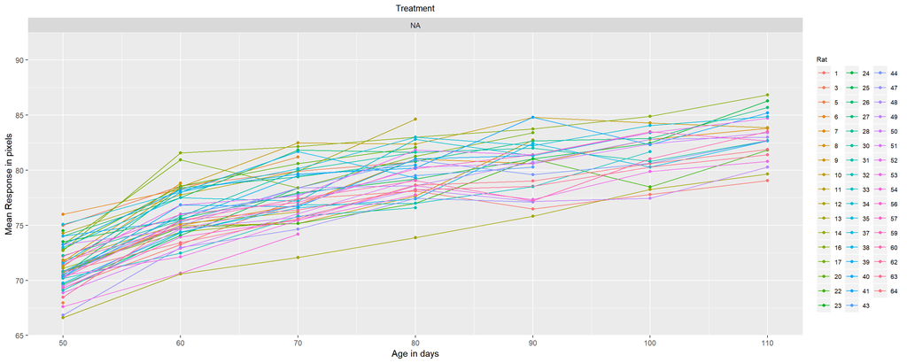

```r
ggplot(data = SkullRats, aes(x = age, y = response, color = as.factor(rat))) + geom_point() +
    geom_line() + facet_wrap(~treat) + theme(legend.title = element_text(size = 8),
    legend.text = element_text(size = 7)) + ylab("Mean Response in pixels") + scale_y_continuous(limits = c(65,
    92.5), breaks = seq(65, 92.5, 5), expand = c(0, 0)) + xlab("Age in days") + scale_x_continuous(limits = c(50,
    110), breaks = seq(50, 110, 10)) + scale_color_discrete(name = "Rat") + ggtitle("Treatment") +
    theme(plot.title = element_text(hjust = 0.5, size = 10))
```

2. Create a graph indicating the mean growth of each group (average over the rats) We would be first required to find the summary data. i.e. find the mean and the confidence intervals. We have used the dplyr package to previously find the means, we will now extend it to find the standard deviation and the sample size for each timepoint/treatment combination. We then calculate the SE’s and we use the critical points of the t-distribution (we don’t naively use 1.96). The code for programming this in R is:

```r
mean_data <- group_by(SkullRats, age, treat) %>% dplyr::summarise(mean.res = mean(response,
    na.rm = TRUE), sd.res = sd(response, na.rm = TRUE), n.res = n()) %>% mutate(se.res = sd.res/sqrt(n.res),
    LCI = mean.res - qt(0.975, n.res - 1) * se.res, UCI = mean.res + qt(0.975, n.res -
        1) * se.res)

View(mean_data)
```

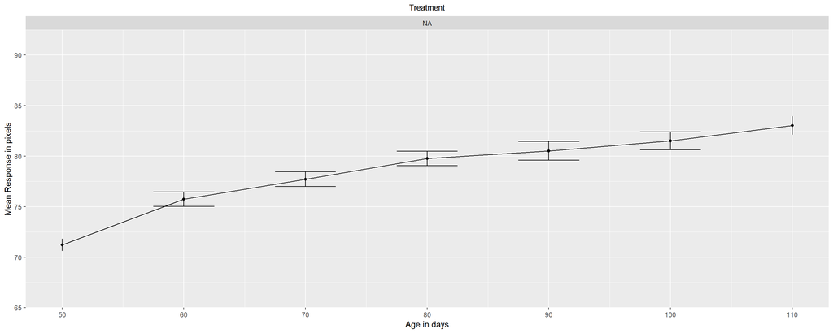

```r
ggplot(data = mean_data, aes(x = age, y = mean.res, ymin = LCI, ymax = UCI)) + geom_point() +
    geom_line() + geom_errorbar(width = 5) + facet_wrap(~treat) + theme(legend.title = element_text(size = 8),
    legend.text = element_text(size = 7)) + ylab("Mean Response in pixels") + scale_y_continuous(limits = c(65,
    92.5), breaks = seq(65, 92.5, 5), expand = c(0, 0)) + xlab("Age in days") + scale_x_continuous(limits = c(50,
    110), breaks = seq(50, 110, 10)) + scale_color_discrete(name = "Rat") + ggtitle("Treatment") +
    theme(plot.title = element_text(hjust = 0.5, size = 10))
```

[figure not shown]

```r
plot.theme = theme_bw() + theme(panel.grid.major = element_blank(), panel.grid.minor = element_blank(),
    panel.border = element_blank(), panel.background = element_blank(), axis.line = element_line(colour = "black",
        size = 1), plot.title = element_text(hjust = 0.5, size = 12, face = "bold"),
    axis.title = element_text(size = 12, face = "bold"), axis.text = element_text(size = 10,
        colour = "black", face = "bold"), legend.title = element_text(size = 12),
    legend.text = element_text(size = 10), legend.position = c(0.8, 0.2))

ggplot(data = mean_data, aes(x = age, y = mean.res, ymin = LCI, ymax = UCI, colour = treat)) +
    plot.theme + geom_point(size = 1.5, position = position_dodge(width = 3)) + geom_line(size = 1,
    position = position_dodge(width = 3)) + geom_errorbar(width = 3, size = 1, position = position_dodge(width = 3)) +
    ylab("Mean Response in pixels") + scale_y_continuous(limits = c(65, 90), breaks = seq(65,
    90, 5), expand = c(0, 0)) + xlab("Age in days") + scale_x_continuous(limits = c(40,
    121), breaks = seq(40, 121, 10), expand = c(0, 0)) + ggtitle("Rat Skull Development") +
    scale_colour_manual(name = " ", breaks = c("Control", "Low dose", "High dose"),
        values = c("red1", "green1", "blue1"))
```